# R programming_lecture 4

chriskt@yonsei.ac.kr

2022-02-12

# **03. Data 입출력 및 EDA**

## **1. 학습 안내**

- 이번 시간에 진행하는 내용에 도움이 되실 유튜브 강의를 아래와 같이 추천드립니다.
  - [R 기초 - 분할 적용 결합 - dplyr 🔑 데이터 변환 | 전처리 | 그룹화 | 파이프 연산자](https://youtu.be/sWyf1_Sk1lk)
  - [이거 외계어 아니야? R 연산자 (operator) 부시기! 고급편!](https://www.youtube.com/watch?v=n2srjwtG1eo)
  - [R프로그래밍 tidyverse로 코딩하는데 모르면 땅을 치고 후회하는 연산자](https://www.youtube.com/watch?v=7RyIP_hpHbY)

## **2. 파일 불러오기**

- R이나 파이썬을 처음 시작하실 때, 가장 많은 분들이 어려움을 겪으시는 것이  
  바로 데이터를 프로그램에서 불러오는 것입니다.
- Rstudio에 GUI 기반으로 편하고 쉽게 불러올 수 있는 기능도 있습니다. 다만,  
  보안이 걸려있거나, 형식에 맞지 않는 문자가 삽입되어 있는 데이터는 에러가 납니다.
- 그래서 저는 엑셀에 있는 데이터를 복사해서 불러오는 것을 가장 자주 사용합니다.

### **2.1 데이터 복사 붙여넣기**

#### **2.1.1. 큰 사이즈 데이터 복사 붙여넣기**

- 엑셀에서 가져오기 원하는 데이터를 선택하시고, Ctrl+c를 눌러주세요.
- 그리고 아래 코드를 실행해주세요.

```r
# 클립보드에 있는 데이터 붙여넣기
mydata <-  read.table("clipboard-16384", sep="\t", fill=T, header = T)
```

##### read.table() 옵션

- R로 불러오고자 하는 데이터의 크기를 보시고, clipboard 뒤쪽 숫자를 넣어주시면 됩니다.  
  clipboard-16384 는 16384kb 크기까지 클립보드의 데이터를 붙여 넣기 하라는 뜻이며  
  이는 약 16mb 크기까지 붙여 넣기 하라는 것입니다.
- 만약 붙여넣기 하고자 하시는 엑셀 데이터가 300mb 크기라면  
  300000kb clipboard-300000 을 넣으시면 됩니다.
- 그 외 아래 옵션을 디폴트로 사용합니다.

  ```
  * sep = "\\t"는 Tab으로 열을 구분하라는 뜻입니다.
  만약 옵션에 "\\," 이렇게 넣으시면 , 로 구분되며,
  데이터가 어떻게 구성되어 있는지에 따라 다르게 넣으시면 됩니다.
  일반적인 엑셀 데이터라면 "\\t" 하시면 됩니다.

  * fill = T 는 비어 있는 셀에는 아무것도 없다는 뜻의 NA를 넣는다는 뜻입니다.

  * header=T 는 엑셀데이터의 첫 행을 열 이름으로 사용한다는 뜻입니다.
  ```

- R에서 생성한 변수를 클립보드로 보내서, 다시 엑셀에 붙여 넣을 수도 있습니다.

```r
# R에 있는 변수를 클립보드로 내보내기
write.table(mydata, file = "clipboard-1694949", sep = "\t", row.names = FALSE)
```

- 이제 다시 엑셀에 가셔서 ctrl+v로 데이터를 붙여넣어보세요.

#### **2.1.2. 작은 사이즈 데이터 붙여넣기**

- 아래 코드를 실행해서 **datapasta** 패키지를 설치합니다.

```r
# data pasta 패키지 활용하기
# install.packages('datapasta')
library(datapasta)
```

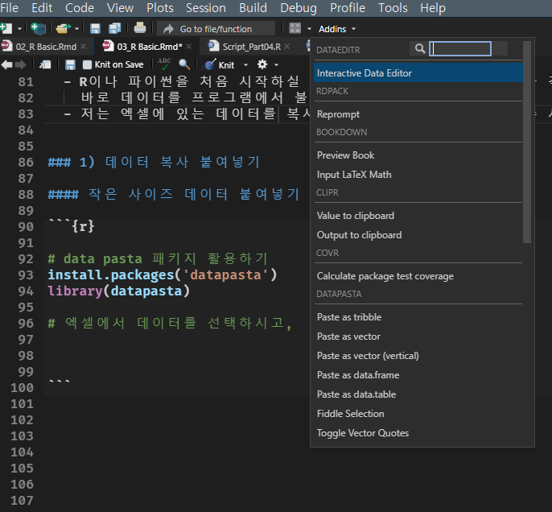

- 그럼 아래와 같은 형태로 곧바로 사용할 수 있도록 데이터가 만들어집니다.

```r
tibble::tribble(
  ~mpg, ~cyl, ~disp,  ~hp, ~drat,   ~wt, ~qsec, ~vs, ~am, ~gear, ~carb,
    21,   6L,   160, 110L,   3.9,  2.62, 16.46,  0L,  1L,    4L,    4L,
    21,   6L,   160, 110L,   3.9, 2.875, 17.02,  0L,  1L,    4L,    4L,
  22.8,   4L,   108,  93L,  3.85,  2.32, 18.61,  1L,  1L,    4L,    1L,
  21.4,   6L,   258, 110L,  3.08, 3.215, 19.44,  1L,  0L,    3L,    1L,
  18.7,   8L,   360, 175L,  3.15,  3.44, 17.02,  0L,  0L,    3L,    2L,
  18.1,   6L,   225, 105L,  2.76,  3.46, 20.22,  1L,  0L,    3L,    1L,
  14.3,   8L,   360, 245L,  3.21,  3.57, 15.84,  0L,  0L,    3L,    4L,
  24.4,   4L, 146.7,  62L,  3.69,  3.19,    20,  1L,  0L,    4L,    2L,
  22.8,   4L, 140.8,  95L,  3.92,  3.15,  22.9,  1L,  0L,    4L,    2L,
  19.2,   6L, 167.6, 123L,  3.92,  3.44,  18.3,  1L,  0L,    4L,    4L,
  17.8,   6L, 167.6, 123L,  3.92,  3.44,  18.9,  1L,  0L,    4L,    4L,
  16.4,   8L, 275.8, 180L,  3.07,  4.07,  17.4,  0L,  0L,    3L,    3L,
  17.3,   8L, 275.8, 180L,  3.07,  3.73,  17.6,  0L,  0L,    3L,    3L,
  15.2,   8L, 275.8, 180L,  3.07,  3.78,    18,  0L,  0L,    3L,    3L,
  10.4,   8L,   472, 205L,  2.93,  5.25, 17.98,  0L,  0L,    3L,    4L,
  10.4,   8L,   460, 215L,     3, 5.424, 17.82,  0L,  0L,    3L,    4L,
  14.7,   8L,   440, 230L,  3.23, 5.345, 17.42,  0L,  0L,    3L,    4L,
  32.4,   4L,  78.7,  66L,  4.08,   2.2, 19.47,  1L,  1L,    4L,    1L,
  30.4,   4L,  75.7,  52L,  4.93, 1.615, 18.52,  1L,  1L,    4L,    2L,
  33.9,   4L,  71.1,  65L,  4.22, 1.835,  19.9,  1L,  1L,    4L,    1L,
  21.5,   4L, 120.1,  97L,   3.7, 2.465, 20.01,  1L,  0L,    3L,    1L,
  15.5,   8L,   318, 150L,  2.76,  3.52, 16.87,  0L,  0L,    3L,    2L,
  15.2,   8L,   304, 150L,  3.15, 3.435,  17.3,  0L,  0L,    3L,    2L,
  13.3,   8L,   350, 245L,  3.73,  3.84, 15.41,  0L,  0L,    3L,    4L,
  19.2,   8L,   400, 175L,  3.08, 3.845, 17.05,  0L,  0L,    3L,    2L,
  27.3,   4L,    79,  66L,  4.08, 1.935,  18.9,  1L,  1L,    4L,    1L,
    26,   4L, 120.3,  91L,  4.43,  2.14,  16.7,  0L,  1L,    5L,    2L,
  30.4,   4L,  95.1, 113L,  3.77, 1.513,  16.9,  1L,  1L,    5L,    2L,
  15.8,   8L,   351, 264L,  4.22,  3.17,  14.5,  0L,  1L,    5L,    4L,
  19.7,   6L,   145, 175L,  3.62,  2.77,  15.5,  0L,  1L,    5L,    6L,
    15,   8L,   301, 335L,  3.54,  3.57,  14.6,  0L,  1L,    5L,    8L,
  21.4,   4L,   121, 109L,  4.11,  2.78,  18.6,  1L,  1L,    4L,    2L
  )
```

### **2.3. Rstudio에서 불러오기**

#### **2.3.1. 파일 포맷에 맞춰 File>import Dataset> 선택해줍니다**

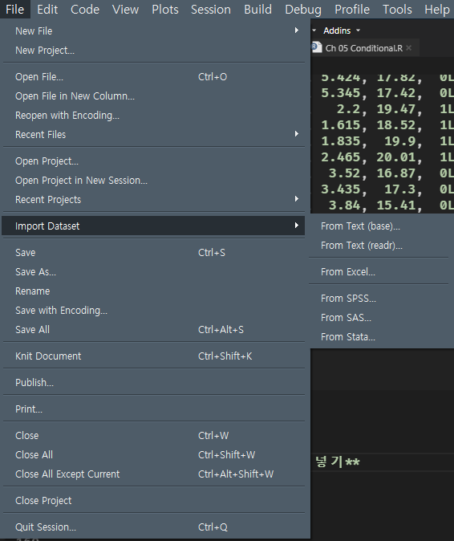

#### **2.3.2. 아래와 같이 Import하는 R 코드와 GUI가 보입니다**

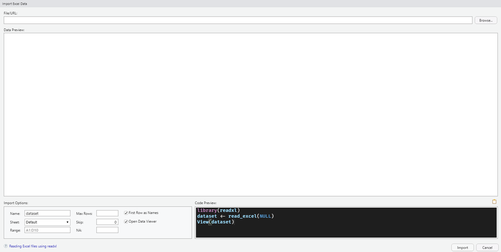

- 수업시간에 함께 해보겠습니다.

## **3. 데이터 확인하기**

### **3.1. 사용할 데이터 다운받기**

- 아래 링크를 클릭하시어 Kaggle 데이터를 다운 받으셔서 엑셀로 파일을 여신 후 셀 전체를 선택하시고 복사(ctrl+c) 해주세요.
- 아래 경로에서 데이터가 다운되지 않는 분께서는, 제가 함꼐 공유드리는 csv 파일 활용하시면 됩니다.

[IBM HR Data Download link](https://www.notion.so/yeahbeeat/IBM-HR-Data-from-Caggle-b5b4753db0a64f5aae4d3d207e14ecf9)

[Kaggle](https://www.kaggle.com/)은 빅데이터 솔루션 대회 플랫폼으로 전 세계 분석가들이 모여 각종 데이터를 분석하고, 경쟁하는 플랫폼입니다. 연습할 수 있는 다양한 분야의 데이터가 올라오기 때문에, 적극 활용을 추천 드립니다.

### **4.2. 복사한 데이터 변수 저장**

> read.table(‘clipboard’) : clipboard에 있는 데이터를 테이블로 읽어오겠다.
- 아래의 코드를 실행하시면 data 변수에 데이터가 복사됩니다.

```r
#kaggle에 올라와 있는 IBM HR data를 복사한 뒤 코드를 실행했습니다
data <- read.table(pipe("pbpaste"), sep="\t", fill=T, header = T)
```

- 오늘 사용할 패키지들을 한번에 설치하고, 로딩해봅니다.

```r
# install.packages('pacman')
pacman::p_load(tidyverse, dlookr, ExPanDaR)
```

- 이제 아래 코드를 실행하여, IBM data가 잘 변수화 되었는지 확인해봅니다.

```r
#IBM HR Data는 향후 기초 통계시 활용할 예정입니다.
# head() 함수를 통해 복사 붙여넣기가 잘 되었는지 확인합니다.
head(data)

#tidy하게 표현
data %>% head()
```

- 이외에도 다양한 옵션이 있으며,아래 링크로 가시면  
  옵션에 대한 설명을 들으실 수 있습니다.

[read.table 함수 option 확인하기](https://www.rdocumentation.org/packages/utils/versions/3.6.2/topics/read.table)